# Risk Factor Analysis

## Outcome Variable

**Outcome Variable:** wast_rec90d

## Predictor Variables

**Intervention Variable:** impfloor

**Adjustment Set:**

- arm
- sex
- W_mage
- meducyrs
- feducyrs
- hhwealth_quart
- hfoodsec
- W_mhtcm
- W_nrooms
- W_nchldlt5
- W_parity
- impsan
- safeh20
- delta_W_mage
- delta_meducyrs
- delta_feducyrs
- delta_hhwealth_quart
- delta_hfoodsec
- delta_W_mhtcm
- delta_W_nrooms
- delta_W_nchldlt5
- delta_W_parity
- delta_impsan
- delta_safeh20

## Stratifying Variables

The analysis was stratified on these variable(s):

- agecat
- studyid
- country

## Data Summary

| agecat | studyid | country | impfloor | wast_rec90d | n_cell | n |
| --- | --- | --- | --- | --- | --- | --- |
| 0-24 months | ki0047075b-MAL-ED | BANGLADESH | 1 | 0 | 38 | 121 |
| 0-24 months | ki0047075b-MAL-ED | BANGLADESH | 1 | 1 | 73 | 121 |
| 0-24 months | ki0047075b-MAL-ED | BANGLADESH | 0 | 0 | 6 | 121 |
| 0-24 months | ki0047075b-MAL-ED | BANGLADESH | 0 | 1 | 4 | 121 |
| 0-24 months | ki0047075b-MAL-ED | BRAZIL | 1 | 0 | 6 | 23 |
| 0-24 months | ki0047075b-MAL-ED | BRAZIL | 1 | 1 | 17 | 23 |
| 0-24 months | ki0047075b-MAL-ED | BRAZIL | 0 | 0 | 0 | 23 |
| 0-24 months | ki0047075b-MAL-ED | BRAZIL | 0 | 1 | 0 | 23 |
| 0-24 months | ki0047075b-MAL-ED | INDIA | 1 | 0 | 61 | 173 |
| 0-24 months | ki0047075b-MAL-ED | INDIA | 1 | 1 | 97 | 173 |
| 0-24 months | ki0047075b-MAL-ED | INDIA | 0 | 0 | 6 | 173 |
| 0-24 months | ki0047075b-MAL-ED | INDIA | 0 | 1 | 9 | 173 |
| 0-24 months | ki0047075b-MAL-ED | NEPAL | 1 | 0 | 9 | 87 |
| 0-24 months | ki0047075b-MAL-ED | NEPAL | 1 | 1 | 32 | 87 |
| 0-24 months | ki0047075b-MAL-ED | NEPAL | 0 | 0 | 10 | 87 |
| 0-24 months | ki0047075b-MAL-ED | NEPAL | 0 | 1 | 36 | 87 |
| 0-24 months | ki0047075b-MAL-ED | PERU | 1 | 0 | 2 | 33 |
| 0-24 months | ki0047075b-MAL-ED | PERU | 1 | 1 | 5 | 33 |
| 0-24 months | ki0047075b-MAL-ED | PERU | 0 | 0 | 4 | 33 |
| 0-24 months | ki0047075b-MAL-ED | PERU | 0 | 1 | 22 | 33 |
| 0-24 months | ki0047075b-MAL-ED | SOUTH AFRICA | 1 | 0 | 12 | 77 |
| 0-24 months | ki0047075b-MAL-ED | SOUTH AFRICA | 1 | 1 | 62 | 77 |
| 0-24 months | ki0047075b-MAL-ED | SOUTH AFRICA | 0 | 0 | 0 | 77 |
| 0-24 months | ki0047075b-MAL-ED | SOUTH AFRICA | 0 | 1 | 3 | 77 |
| 0-24 months | ki0047075b-MAL-ED | TANZANIA, UNITED REPUBLIC OF | 1 | 0 | 0 | 45 |
| 0-24 months | ki0047075b-MAL-ED | TANZANIA, UNITED REPUBLIC OF | 1 | 1 | 1 | 45 |
| 0-24 months | ki0047075b-MAL-ED | TANZANIA, UNITED REPUBLIC OF | 0 | 0 | 8 | 45 |
| 0-24 months | ki0047075b-MAL-ED | TANZANIA, UNITED REPUBLIC OF | 0 | 1 | 36 | 45 |
| 0-24 months | ki1000108-CMC-V-BCS-2002 | INDIA | 1 | 0 | 78 | 225 |
| 0-24 months | ki1000108-CMC-V-BCS-2002 | INDIA | 1 | 1 | 147 | 225 |

[output cut: 162 more lines]

The following strata were considered:

- agecat: 0-24 months, studyid: ki0047075b-MAL-ED, country: BANGLADESH
- agecat: 0-24 months, studyid: ki0047075b-MAL-ED, country: BRAZIL
- agecat: 0-24 months, studyid: ki0047075b-MAL-ED, country: INDIA
- agecat: 0-24 months, studyid: ki0047075b-MAL-ED, country: NEPAL
- agecat: 0-24 months, studyid: ki0047075b-MAL-ED, country: PERU
- agecat: 0-24 months, studyid: ki0047075b-MAL-ED, country: SOUTH AFRICA
- agecat: 0-24 months, studyid: ki0047075b-MAL-ED, country: TANZANIA, UNITED REPUBLIC OF
- agecat: 0-24 months, studyid: ki1000108-CMC-V-BCS-2002, country: INDIA
- agecat: 0-24 months, studyid: ki1000108-IRC, country: INDIA
- agecat: 0-24 months, studyid: ki1017093-NIH-Birth, country: BANGLADESH
- agecat: 0-24 months, studyid: ki1017093b-PROVIDE, country: BANGLADESH
- agecat: 0-24 months, studyid: ki1017093c-NIH-Crypto, country: BANGLADESH
- agecat: 0-24 months, studyid: ki1113344-GMS-Nepal, country: NEPAL
- agecat: 0-24 months, studyid: ki1114097-CONTENT, country: PERU
- agecat: 0-24 months, studyid: kiGH5241-JiVitA-3, country: BANGLADESH
- agecat: 0-24 months, studyid: kiGH5241-JiVitA-4, country: BANGLADESH
- agecat: 0-6 months, studyid: ki0047075b-MAL-ED, country: BANGLADESH
- agecat: 0-6 months, studyid: ki0047075b-MAL-ED, country: BRAZIL
- agecat: 0-6 months, studyid: ki0047075b-MAL-ED, country: INDIA
- agecat: 0-6 months, studyid: ki0047075b-MAL-ED, country: NEPAL
- agecat: 0-6 months, studyid: ki0047075b-MAL-ED, country: PERU
- agecat: 0-6 months, studyid: ki0047075b-MAL-ED, country: SOUTH AFRICA
- agecat: 0-6 months, studyid: ki0047075b-MAL-ED, country: TANZANIA, UNITED REPUBLIC OF
- agecat: 0-6 months, studyid: ki1000108-CMC-V-BCS-2002, country: INDIA
- agecat: 0-6 months, studyid: ki1000108-IRC, country: INDIA
- agecat: 0-6 months, studyid: ki1017093-NIH-Birth, country: BANGLADESH
- agecat: 0-6 months, studyid: ki1017093b-PROVIDE, country: BANGLADESH
- agecat: 0-6 months, studyid: ki1017093c-NIH-Crypto, country: BANGLADESH
- agecat: 0-6 months, studyid: ki1113344-GMS-Nepal, country: NEPAL
- agecat: 0-6 months, studyid: ki1114097-CONTENT, country: PERU
- agecat: 0-6 months, studyid: kiGH5241-JiVitA-3, country: BANGLADESH
- agecat: 0-6 months, studyid: kiGH5241-JiVitA-4, country: BANGLADESH
- agecat: 6-24 months, studyid: ki0047075b-MAL-ED, country: BANGLADESH
- agecat: 6-24 months, studyid: ki0047075b-MAL-ED, country: BRAZIL
- agecat: 6-24 months, studyid: ki0047075b-MAL-ED, country: INDIA
- agecat: 6-24 months, studyid: ki0047075b-MAL-ED, country: NEPAL
- agecat: 6-24 months, studyid: ki0047075b-MAL-ED, country: PERU
- agecat: 6-24 months, studyid: ki0047075b-MAL-ED, country: SOUTH AFRICA
- agecat: 6-24 months, studyid: ki0047075b-MAL-ED, country: TANZANIA, UNITED REPUBLIC OF
- agecat: 6-24 months, studyid: ki1000108-CMC-V-BCS-2002, country: INDIA
- agecat: 6-24 months, studyid: ki1000108-IRC, country: INDIA
- agecat: 6-24 months, studyid: ki1017093-NIH-Birth, country: BANGLADESH
- agecat: 6-24 months, studyid: ki1017093b-PROVIDE, country: BANGLADESH
- agecat: 6-24 months, studyid: ki1017093c-NIH-Crypto, country: BANGLADESH
- agecat: 6-24 months, studyid: ki1113344-GMS-Nepal, country: NEPAL
- agecat: 6-24 months, studyid: ki1114097-CONTENT, country: PERU
- agecat: 6-24 months, studyid: kiGH5241-JiVitA-3, country: BANGLADESH
- agecat: 6-24 months, studyid: kiGH5241-JiVitA-4, country: BANGLADESH

### Dropped Strata

Some strata were dropped due to rare outcomes:

- agecat: 0-24 months, studyid: ki0047075b-MAL-ED, country: BANGLADESH
- agecat: 0-24 months, studyid: ki0047075b-MAL-ED, country: BRAZIL
- agecat: 0-24 months, studyid: ki0047075b-MAL-ED, country: PERU
- agecat: 0-24 months, studyid: ki0047075b-MAL-ED, country: SOUTH AFRICA
- agecat: 0-24 months, studyid: ki0047075b-MAL-ED, country: TANZANIA, UNITED REPUBLIC OF
- agecat: 0-24 months, studyid: ki1000108-CMC-V-BCS-2002, country: INDIA
- agecat: 0-24 months, studyid: ki1000108-IRC, country: INDIA
- agecat: 0-24 months, studyid: ki1114097-CONTENT, country: PERU
- agecat: 0-6 months, studyid: ki0047075b-MAL-ED, country: BANGLADESH
- agecat: 0-6 months, studyid: ki0047075b-MAL-ED, country: BRAZIL
- agecat: 0-6 months, studyid: ki0047075b-MAL-ED, country: INDIA
- agecat: 0-6 months, studyid: ki0047075b-MAL-ED, country: NEPAL
- agecat: 0-6 months, studyid: ki0047075b-MAL-ED, country: PERU
- agecat: 0-6 months, studyid: ki0047075b-MAL-ED, country: SOUTH AFRICA
- agecat: 0-6 months, studyid: ki0047075b-MAL-ED, country: TANZANIA, UNITED REPUBLIC OF
- agecat: 0-6 months, studyid: ki1000108-CMC-V-BCS-2002, country: INDIA
- agecat: 0-6 months, studyid: ki1000108-IRC, country: INDIA
- agecat: 0-6 months, studyid: ki1017093c-NIH-Crypto, country: BANGLADESH
- agecat: 0-6 months, studyid: ki1114097-CONTENT, country: PERU
- agecat: 6-24 months, studyid: ki0047075b-MAL-ED, country: BANGLADESH
- agecat: 6-24 months, studyid: ki0047075b-MAL-ED, country: BRAZIL
- agecat: 6-24 months, studyid: ki0047075b-MAL-ED, country: NEPAL
- agecat: 6-24 months, studyid: ki0047075b-MAL-ED, country: PERU
- agecat: 6-24 months, studyid: ki0047075b-MAL-ED, country: SOUTH AFRICA
- agecat: 6-24 months, studyid: ki0047075b-MAL-ED, country: TANZANIA, UNITED REPUBLIC OF
- agecat: 6-24 months, studyid: ki1000108-CMC-V-BCS-2002, country: INDIA
- agecat: 6-24 months, studyid: ki1000108-IRC, country: INDIA
- agecat: 6-24 months, studyid: ki1017093b-PROVIDE, country: BANGLADESH
- agecat: 6-24 months, studyid: ki1017093c-NIH-Crypto, country: BANGLADESH
- agecat: 6-24 months, studyid: ki1114097-CONTENT, country: PERU
- agecat: 6-24 months, studyid: kiGH5241-JiVitA-3, country: BANGLADESH

## Methods Detail

We’re interested in the causal parameters $E[Y_a]$ for all values of $a \in \mathcal{A}$. These parameters represent the mean outcome if, possibly contrary to fact, we intervened to set all units to have $A=a$. Under the randomization and positivity assumptions, these are identified by the statistical parameters $\psi_a=E_W[E_{Y|A,W}(Y|A=a,W)]$. In addition, we’re interested in the mean of $Y$, $E[Y]$ under no intervention (the observed mean). We will estimate these parameters by using SuperLearner to fit the relevant likelihood factors – $E_{Y|A,W}(Y|A=a,W)$ and $p(A=a|W)$, and then updating our likelihood fit using a joint TMLE.

For unadjusted analyses ($W=\{\}$), initial likelihoods were estimated using Lrnr_glm to estimate the simple $E(Y|A)$ and Lrnr_mean to estimate $p(A)$. For adjusted analyses, a small library containing Lrnr_glmnet, Lrnr_xgboost, and Lrnr_mean was used.

Having estimated these parameters, we will then use the delta method to estimate relative risks and attributable risks relative to a prespecified baseline level of $A$.

# Results Detail

## Results Plots

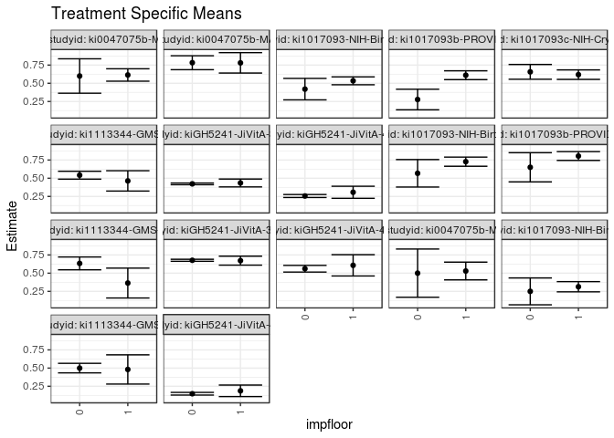

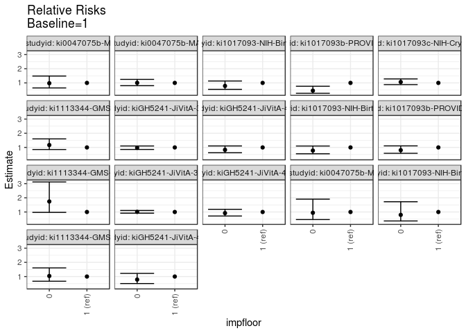

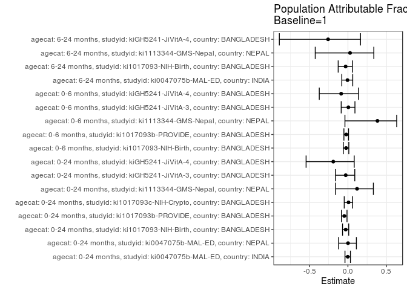

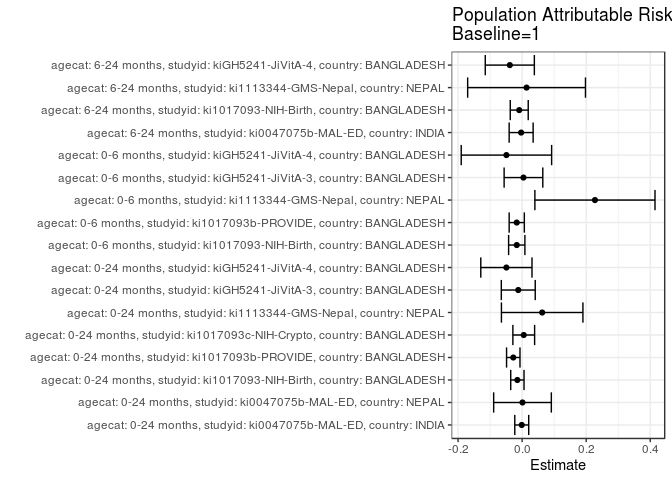

## Results Table

### Parameter: TSM

| agecat | studyid | country | intervention_level | baseline_level | estimate | ci_lower | ci_upper |
| --- | --- | --- | --- | --- | --- | --- | --- |
| 0-24 months | ki0047075b-MAL-ED | INDIA | 1 | NA | 0.6139241 | 0.5287779 | 0.6990702 |
| 0-24 months | ki0047075b-MAL-ED | INDIA | 0 | NA | 0.6000000 | 0.3636292 | 0.8363708 |
| 0-24 months | ki0047075b-MAL-ED | NEPAL | 1 | NA | 0.7804878 | 0.6404037 | 0.9205719 |
| 0-24 months | ki0047075b-MAL-ED | NEPAL | 0 | NA | 0.7826087 | 0.6870003 | 0.8782171 |
| 0-24 months | ki1017093-NIH-Birth | BANGLADESH | 1 | NA | 0.5340204 | 0.4797659 | 0.5882748 |
| 0-24 months | ki1017093-NIH-Birth | BANGLADESH | 0 | NA | 0.4198071 | 0.2723470 | 0.5672671 |
| 0-24 months | ki1017093b-PROVIDE | BANGLADESH | 1 | NA | 0.6107348 | 0.5500672 | 0.6714025 |
| 0-24 months | ki1017093b-PROVIDE | BANGLADESH | 0 | NA | 0.2773060 | 0.1357883 | 0.4188237 |
| 0-24 months | ki1017093c-NIH-Crypto | BANGLADESH | 1 | NA | 0.6187680 | 0.5535542 | 0.6839817 |
| 0-24 months | ki1017093c-NIH-Crypto | BANGLADESH | 0 | NA | 0.6569556 | 0.5556238 | 0.7582874 |
| 0-24 months | ki1113344-GMS-Nepal | NEPAL | 1 | NA | 0.4632589 | 0.3236711 | 0.6028467 |
| 0-24 months | ki1113344-GMS-Nepal | NEPAL | 0 | NA | 0.5416570 | 0.4875832 | 0.5957307 |
| 0-24 months | kiGH5241-JiVitA-3 | BANGLADESH | 1 | NA | 0.4348818 | 0.3808949 | 0.4888686 |
| 0-24 months | kiGH5241-JiVitA-3 | BANGLADESH | 0 | NA | 0.4225285 | 0.4107342 | 0.4343229 |
| 0-24 months | kiGH5241-JiVitA-4 | BANGLADESH | 1 | NA | 0.3071741 | 0.2241992 | 0.3901491 |
| 0-24 months | kiGH5241-JiVitA-4 | BANGLADESH | 0 | NA | 0.2558902 | 0.2353594 | 0.2764210 |
| 0-6 months | ki1017093-NIH-Birth | BANGLADESH | 1 | NA | 0.7272059 | 0.6642278 | 0.7901840 |
| 0-6 months | ki1017093-NIH-Birth | BANGLADESH | 0 | NA | 0.5676077 | 0.3789011 | 0.7563144 |
| 0-6 months | ki1017093b-PROVIDE | BANGLADESH | 1 | NA | 0.8048780 | 0.7444925 | 0.8652636 |
| 0-6 months | ki1017093b-PROVIDE | BANGLADESH | 0 | NA | 0.6500000 | 0.4495198 | 0.8504802 |
| 0-6 months | ki1113344-GMS-Nepal | NEPAL | 1 | NA | 0.3642048 | 0.1589912 | 0.5694183 |
| 0-6 months | ki1113344-GMS-Nepal | NEPAL | 0 | NA | 0.6339655 | 0.5456407 | 0.7222903 |
| 0-6 months | kiGH5241-JiVitA-3 | BANGLADESH | 1 | NA | 0.6717194 | 0.6102213 | 0.7332175 |
| 0-6 months | kiGH5241-JiVitA-3 | BANGLADESH | 0 | NA | 0.6767497 | 0.6627063 | 0.6907931 |
| 0-6 months | kiGH5241-JiVitA-4 | BANGLADESH | 1 | NA | 0.6074516 | 0.4615665 | 0.7533366 |
| 0-6 months | kiGH5241-JiVitA-4 | BANGLADESH | 0 | NA | 0.5610809 | 0.5151459 | 0.6070158 |
| 6-24 months | ki0047075b-MAL-ED | INDIA | 1 | NA | 0.5294118 | 0.4074100 | 0.6514135 |
| 6-24 months | ki0047075b-MAL-ED | INDIA | 0 | NA | 0.5000000 | 0.1687592 | 0.8312408 |
| 6-24 months | ki1017093-NIH-Birth | BANGLADESH | 1 | NA | 0.3136095 | 0.2434845 | 0.3837345 |
| 6-24 months | ki1017093-NIH-Birth | BANGLADESH | 0 | NA | 0.2500000 | 0.0656374 | 0.4343626 |
| 6-24 months | ki1113344-GMS-Nepal | NEPAL | 1 | NA | 0.4812302 | 0.2804918 | 0.6819687 |
| 6-24 months | ki1113344-GMS-Nepal | NEPAL | 0 | NA | 0.4996954 | 0.4341651 | 0.5652256 |
| 6-24 months | kiGH5241-JiVitA-4 | BANGLADESH | 1 | NA | 0.1877684 | 0.1087864 | 0.2667503 |
| 6-24 months | kiGH5241-JiVitA-4 | BANGLADESH | 0 | NA | 0.1476655 | 0.1291248 | 0.1662061 |

### Parameter: E(Y)

| agecat | studyid | country | intervention_level | baseline_level | estimate | ci_lower | ci_upper |
| --- | --- | --- | --- | --- | --- | --- | --- |
| 0-24 months | ki0047075b-MAL-ED | INDIA | NA | NA | 0.6127168 | 0.5323061 | 0.6931274 |
| 0-24 months | ki0047075b-MAL-ED | NEPAL | NA | NA | 0.7816092 | 0.6987929 | 0.8644255 |
| 0-24 months | ki1017093-NIH-Birth | BANGLADESH | NA | NA | 0.5191388 | 0.4683286 | 0.5699489 |
| 0-24 months | ki1017093b-PROVIDE | BANGLADESH | NA | NA | 0.5830619 | 0.5262762 | 0.6398476 |
| 0-24 months | ki1017093c-NIH-Crypto | BANGLADESH | NA | NA | 0.6237942 | 0.5698223 | 0.6777662 |
| 0-24 months | ki1113344-GMS-Nepal | NEPAL | NA | NA | 0.5258427 | 0.4754454 | 0.5762400 |
| 0-24 months | kiGH5241-JiVitA-3 | BANGLADESH | NA | NA | 0.4228375 | 0.4116972 | 0.4339777 |
| 0-24 months | kiGH5241-JiVitA-4 | BANGLADESH | NA | NA | 0.2580019 | 0.2386523 | 0.2773515 |
| 0-6 months | ki1017093-NIH-Birth | BANGLADESH | NA | NA | 0.7104072 | 0.6505603 | 0.7702542 |
| 0-6 months | ki1017093b-PROVIDE | BANGLADESH | NA | NA | 0.7880435 | 0.7295878 | 0.8464992 |
| 0-6 months | ki1113344-GMS-Nepal | NEPAL | NA | NA | 0.5915493 | 0.5100380 | 0.6730606 |
| 0-6 months | kiGH5241-JiVitA-3 | BANGLADESH | NA | NA | 0.6758416 | 0.6624927 | 0.6891906 |
| 0-6 months | kiGH5241-JiVitA-4 | BANGLADESH | NA | NA | 0.5583942 | 0.5167799 | 0.6000084 |
| 6-24 months | ki0047075b-MAL-ED | INDIA | NA | NA | 0.5263158 | 0.4116286 | 0.6410029 |
| 6-24 months | ki1017093-NIH-Birth | BANGLADESH | NA | NA | 0.3045685 | 0.2390070 | 0.3701301 |
| 6-24 months | ki1113344-GMS-Nepal | NEPAL | NA | NA | 0.4950495 | 0.4335437 | 0.5565553 |
| 6-24 months | kiGH5241-JiVitA-4 | BANGLADESH | NA | NA | 0.1492734 | 0.1316631 | 0.1668838 |

### Parameter: RR

| agecat | studyid | country | intervention_level | baseline_level | estimate | ci_lower | ci_upper |
| --- | --- | --- | --- | --- | --- | --- | --- |
| 0-24 months | ki0047075b-MAL-ED | INDIA | 1 | 1 | 1.0000000 | 1.0000000 | 1.0000000 |
| 0-24 months | ki0047075b-MAL-ED | INDIA | 0 | 1 | 0.9773196 | 0.6436676 | 1.4839237 |
| 0-24 months | ki0047075b-MAL-ED | NEPAL | 1 | 1 | 1.0000000 | 1.0000000 | 1.0000000 |
| 0-24 months | ki0047075b-MAL-ED | NEPAL | 0 | 1 | 1.0027174 | 0.8063445 | 1.2469140 |
| 0-24 months | ki1017093-NIH-Birth | BANGLADESH | 1 | 1 | 1.0000000 | 1.0000000 | 1.0000000 |
| 0-24 months | ki1017093-NIH-Birth | BANGLADESH | 0 | 1 | 0.7861255 | 0.5451090 | 1.1337060 |
| 0-24 months | ki1017093b-PROVIDE | BANGLADESH | 1 | 1 | 1.0000000 | 1.0000000 | 1.0000000 |
| 0-24 months | ki1017093b-PROVIDE | BANGLADESH | 0 | 1 | 0.4540530 | 0.2694927 | 0.7650082 |
| 0-24 months | ki1017093c-NIH-Crypto | BANGLADESH | 1 | 1 | 1.0000000 | 1.0000000 | 1.0000000 |
| 0-24 months | ki1017093c-NIH-Crypto | BANGLADESH | 0 | 1 | 1.0617156 | 0.8799764 | 1.2809889 |
| 0-24 months | ki1113344-GMS-Nepal | NEPAL | 1 | 1 | 1.0000000 | 1.0000000 | 1.0000000 |
| 0-24 months | ki1113344-GMS-Nepal | NEPAL | 0 | 1 | 1.1692316 | 0.8515083 | 1.6055070 |
| 0-24 months | kiGH5241-JiVitA-3 | BANGLADESH | 1 | 1 | 1.0000000 | 1.0000000 | 1.0000000 |
| 0-24 months | kiGH5241-JiVitA-3 | BANGLADESH | 0 | 1 | 0.9715941 | 0.8556383 | 1.1032641 |
| 0-24 months | kiGH5241-JiVitA-4 | BANGLADESH | 1 | 1 | 1.0000000 | 1.0000000 | 1.0000000 |
| 0-24 months | kiGH5241-JiVitA-4 | BANGLADESH | 0 | 1 | 0.8330461 | 0.6283986 | 1.1043400 |
| 0-6 months | ki1017093-NIH-Birth | BANGLADESH | 1 | 1 | 1.0000000 | 1.0000000 | 1.0000000 |
| 0-6 months | ki1017093-NIH-Birth | BANGLADESH | 0 | 1 | 0.7805324 | 0.5540411 | 1.0996129 |
| 0-6 months | ki1017093b-PROVIDE | BANGLADESH | 1 | 1 | 1.0000000 | 1.0000000 | 1.0000000 |
| 0-6 months | ki1017093b-PROVIDE | BANGLADESH | 0 | 1 | 0.8075758 | 0.5879304 | 1.1092786 |
| 0-6 months | ki1113344-GMS-Nepal | NEPAL | 1 | 1 | 1.0000000 | 1.0000000 | 1.0000000 |
| 0-6 months | ki1113344-GMS-Nepal | NEPAL | 0 | 1 | 1.7406842 | 0.9724889 | 3.1156979 |
| 0-6 months | kiGH5241-JiVitA-3 | BANGLADESH | 1 | 1 | 1.0000000 | 1.0000000 | 1.0000000 |
| 0-6 months | kiGH5241-JiVitA-3 | BANGLADESH | 0 | 1 | 1.0074887 | 0.9174392 | 1.1063769 |
| 0-6 months | kiGH5241-JiVitA-4 | BANGLADESH | 1 | 1 | 1.0000000 | 1.0000000 | 1.0000000 |
| 0-6 months | kiGH5241-JiVitA-4 | BANGLADESH | 0 | 1 | 0.9236635 | 0.7166581 | 1.1904621 |
| 6-24 months | ki0047075b-MAL-ED | INDIA | 1 | 1 | 1.0000000 | 1.0000000 | 1.0000000 |
| 6-24 months | ki0047075b-MAL-ED | INDIA | 0 | 1 | 0.9444444 | 0.4683311 | 1.9045828 |
| 6-24 months | ki1017093-NIH-Birth | BANGLADESH | 1 | 1 | 1.0000000 | 1.0000000 | 1.0000000 |
| 6-24 months | ki1017093-NIH-Birth | BANGLADESH | 0 | 1 | 0.7971698 | 0.3690609 | 1.7218829 |
| 6-24 months | ki1113344-GMS-Nepal | NEPAL | 1 | 1 | 1.0000000 | 1.0000000 | 1.0000000 |
| 6-24 months | ki1113344-GMS-Nepal | NEPAL | 0 | 1 | 1.0383707 | 0.6702442 | 1.6086880 |
| 6-24 months | kiGH5241-JiVitA-4 | BANGLADESH | 1 | 1 | 1.0000000 | 1.0000000 | 1.0000000 |
| 6-24 months | kiGH5241-JiVitA-4 | BANGLADESH | 0 | 1 | 0.7864234 | 0.5069573 | 1.2199485 |

### Parameter: PAR

| agecat | studyid | country | intervention_level | baseline_level | estimate | ci_lower | ci_upper |
| --- | --- | --- | --- | --- | --- | --- | --- |
| 0-24 months | ki0047075b-MAL-ED | INDIA | 1 | NA | -0.0012073 | -0.0229540 | 0.0205394 |
| 0-24 months | ki0047075b-MAL-ED | NEPAL | 1 | NA | 0.0011214 | -0.0889347 | 0.0911775 |
| 0-24 months | ki1017093-NIH-Birth | BANGLADESH | 1 | NA | -0.0148816 | -0.0356696 | 0.0059064 |
| 0-24 months | ki1017093b-PROVIDE | BANGLADESH | 1 | NA | -0.0276730 | -0.0486293 | -0.0067167 |
| 0-24 months | ki1017093c-NIH-Crypto | BANGLADESH | 1 | NA | 0.0050262 | -0.0289135 | 0.0389660 |
| 0-24 months | ki1113344-GMS-Nepal | NEPAL | 1 | NA | 0.0625838 | -0.0646409 | 0.1898085 |
| 0-24 months | kiGH5241-JiVitA-3 | BANGLADESH | 1 | NA | -0.0120443 | -0.0650077 | 0.0409192 |
| 0-24 months | kiGH5241-JiVitA-4 | BANGLADESH | 1 | NA | -0.0491722 | -0.1291250 | 0.0307806 |
| 0-6 months | ki1017093-NIH-Birth | BANGLADESH | 1 | NA | -0.0167986 | -0.0422238 | 0.0086265 |
| 0-6 months | ki1017093b-PROVIDE | BANGLADESH | 1 | NA | -0.0168346 | -0.0405172 | 0.0068480 |
| 0-6 months | ki1113344-GMS-Nepal | NEPAL | 1 | NA | 0.2273445 | 0.0397952 | 0.4148938 |
| 0-6 months | kiGH5241-JiVitA-3 | BANGLADESH | 1 | NA | 0.0041222 | -0.0562411 | 0.0644856 |
| 0-6 months | kiGH5241-JiVitA-4 | BANGLADESH | 1 | NA | -0.0490574 | -0.1902055 | 0.0920907 |
| 6-24 months | ki0047075b-MAL-ED | INDIA | 1 | NA | -0.0030960 | -0.0405454 | 0.0343534 |
| 6-24 months | ki1017093-NIH-Birth | BANGLADESH | 1 | NA | -0.0090409 | -0.0370914 | 0.0190095 |
| 6-24 months | ki1113344-GMS-Nepal | NEPAL | 1 | NA | 0.0138193 | -0.1701328 | 0.1977714 |
| 6-24 months | kiGH5241-JiVitA-4 | BANGLADESH | 1 | NA | -0.0384949 | -0.1151334 | 0.0381436 |

### Parameter: PAF

| agecat | studyid | country | intervention_level | baseline_level | estimate | ci_lower | ci_upper |
| --- | --- | --- | --- | --- | --- | --- | --- |
| 0-24 months | ki0047075b-MAL-ED | INDIA | 1 | NA | -0.0019704 | -0.0380759 | 0.0328793 |
| 0-24 months | ki0047075b-MAL-ED | NEPAL | 1 | NA | 0.0014347 | -0.1207479 | 0.1102972 |
| 0-24 months | ki1017093-NIH-Birth | BANGLADESH | 1 | NA | -0.0286660 | -0.0696976 | 0.0107917 |
| 0-24 months | ki1017093b-PROVIDE | BANGLADESH | 1 | NA | -0.0474614 | -0.0842999 | -0.0118745 |
| 0-24 months | ki1017093c-NIH-Crypto | BANGLADESH | 1 | NA | 0.0080575 | -0.0479133 | 0.0610389 |
| 0-24 months | ki1113344-GMS-Nepal | NEPAL | 1 | NA | 0.1190162 | -0.1606532 | 0.3312968 |
| 0-24 months | kiGH5241-JiVitA-3 | BANGLADESH | 1 | NA | -0.0284844 | -0.1617014 | 0.0894560 |
| 0-24 months | kiGH5241-JiVitA-4 | BANGLADESH | 1 | NA | -0.1905885 | -0.5442702 | 0.0820901 |
| 0-6 months | ki1017093-NIH-Birth | BANGLADESH | 1 | NA | -0.0236465 | -0.0603033 | 0.0117430 |
| 0-6 months | ki1017093b-PROVIDE | BANGLADESH | 1 | NA | -0.0213625 | -0.0520989 | 0.0084760 |
| 0-6 months | ki1113344-GMS-Nepal | NEPAL | 1 | NA | 0.3843205 | -0.0386018 | 0.6350273 |
| 0-6 months | kiGH5241-JiVitA-3 | BANGLADESH | 1 | NA | 0.0060994 | -0.0873493 | 0.0915170 |
| 0-6 months | kiGH5241-JiVitA-4 | BANGLADESH | 1 | NA | -0.0878545 | -0.3727787 | 0.1379329 |
| 6-24 months | ki0047075b-MAL-ED | INDIA | 1 | NA | -0.0058824 | -0.0795730 | 0.0627782 |
| 6-24 months | ki1017093-NIH-Birth | BANGLADESH | 1 | NA | -0.0296844 | -0.1265874 | 0.0588835 |
| 6-24 months | ki1113344-GMS-Nepal | NEPAL | 1 | NA | 0.0279150 | -0.4252965 | 0.3370156 |
| 6-24 months | kiGH5241-JiVitA-4 | BANGLADESH | 1 | NA | -0.2578820 | -0.8923347 | 0.1638546 |